# Project Python Foundations: FoodHub Data Analysis

**Marks: 60**

### Context

The number of restaurants in New York is increasing day by day. Lots of students and busy professionals rely on those restaurants due to their hectic lifestyles. Online food delivery service is a great option for them. It provides them with good food from their favorite restaurants. A food aggregator company FoodHub offers access to multiple restaurants through a single smartphone app.

The app allows the restaurants to receive a direct online order from a customer. The app assigns a delivery person from the company to pick up the order after it is confirmed by the restaurant. The delivery person then uses the map to reach the restaurant and waits for the food package. Once the food package is handed over to the delivery person, he/she confirms the pick-up in the app and travels to the customer's location to deliver the food. The delivery person confirms the drop-off in the app after delivering the food package to the customer. The customer can rate the order in the app. The food aggregator earns money by collecting a fixed margin of the delivery order from the restaurants.

### Objective

The food aggregator company has stored the data of the different orders made by the registered customers in their online portal. They want to analyze the data to get a fair idea about the demand of different restaurants which will help them in enhancing their customer experience. Suppose you are hired as a Data Scientist in this company and the Data Science team has shared some of the key questions that need to be answered. Perform the data analysis to find answers to these questions that will help the company to improve the business.

### Data Description

The data contains the different data related to a food order. The detailed data dictionary is given below.

### Data Dictionary

- order_id: Unique ID of the order
- customer_id: ID of the customer who ordered the food
- restaurant_name: Name of the restaurant
- cuisine_type: Cuisine ordered by the customer
- cost: Cost of the order
- day_of_the_week: Indicates whether the order is placed on a weekday or weekend (The weekday is from Monday to Friday and the weekend is Saturday and Sunday)
- rating: Rating given by the customer out of 5
- food_preparation_time: Time (in minutes) taken by the restaurant to prepare the food. This is calculated by taking the difference between the timestamps of the restaurant's order confirmation and the delivery person's pick-up confirmation.
- delivery_time: Time (in minutes) taken by the delivery person to deliver the food package. This is calculated by taking the difference between the timestamps of the delivery person's pick-up confirmation and drop-off information

### Let us start by importing the required libraries

```python
#In order to remove future warning notifs from pandas
import warnings
warnings.simplefilter(action='ignore', category=FutureWarning)

# import libraries for data manipulation
import numpy as np
import pandas as pd
pd.options.mode.chained_assignment = None

# import libraries for data visualization
import matplotlib.pyplot as plt
import seaborn as sns
```

### Understanding the structure of the data

```python
# read the data
df = pd.read_csv('foodhub_order.csv')
df_copy = df # Copy created to preserve the original data
df.head()
```

|  | order_id | customer_id | restaurant_name | cuisine_type | cost_of_the_order | day_of_the_week | rating | food_preparation_time | delivery_time |
| --- | --- | --- | --- | --- | --- | --- | --- | --- | --- |
| 0 | 1477147 | 337525 | Hangawi | Korean | 30.75 | Weekend | Not given | 25 | 20 |
| 1 | 1477685 | 358141 | Blue Ribbon Sushi Izakaya | Japanese | 12.08 | Weekend | Not given | 25 | 23 |
| 2 | 1477070 | 66393 | Cafe Habana | Mexican | 12.23 | Weekday | 5 | 23 | 28 |
| 3 | 1477334 | 106968 | Blue Ribbon Fried Chicken | American | 29.20 | Weekend | 3 | 25 | 15 |
| 4 | 1478249 | 76942 | Dirty Bird to Go | American | 11.59 | Weekday | 4 | 25 | 24 |

#### Observations:

The DataFrame has 9 columns as mentioned in the Data Dictionary. Data in each row corresponds to the order placed by a customer.

### **Question 1:** How many rows and columns are present in the data? [0.5 mark]

```python
df.shape
```

```
(1898, 9)
```

#### Observations:

#### - 1898 Rows and 9 Columns are present in this dataset

### **Question 2:** What are the datatypes of the different columns in the dataset? (The info() function can be used) [0.5 mark]

```python
df.info()
```

```
<class 'pandas.core.frame.DataFrame'>
RangeIndex: 1898 entries, 0 to 1897
Data columns (total 9 columns):
 #   Column                 Non-Null Count  Dtype
---  ------                 --------------  -----
 0   order_id               1898 non-null   int64
 1   customer_id            1898 non-null   int64
 2   restaurant_name        1898 non-null   object
 3   cuisine_type           1898 non-null   object
 4   cost_of_the_order      1898 non-null   float64
 5   day_of_the_week        1898 non-null   object
 6   rating                 1898 non-null   object
 7   food_preparation_time  1898 non-null   int64
 8   delivery_time          1898 non-null   int64
dtypes: float64(1), int64(4), object(4)
memory usage: 133.6+ KB
```

#### Observations:

#### - 4 Columns of datatype integer (order_id, customer_id, food_preparation time and delivery_time)

#### - 4 Columns of the object datatype (restaurant_name, cuisine_type, day_of_the_week and rating)

#### - 1 Column of datatype float (cost_of_the_order)

### **Question 3:** Are there any missing values in the data? If yes, treat them using an appropriate method. [1 mark]

```python
df.isnull().sum()
```

```
order_id                 0
customer_id              0
restaurant_name          0
cuisine_type             0
cost_of_the_order        0
day_of_the_week          0
rating                   0
food_preparation_time    0
delivery_time            0
dtype: int64
```

#### Observations:

#### No null values are present within the dataset however, some orders were not rated by the customer. Filling those ratings through imputation doesn't feel like the right choice due to it potentially misrepresenting the individual customer's feedback for each row, thus the data will be left as is

### **Question 4:** Check the statistical summary of the data. What is the minimum, average, and maximum time it takes for food to be prepared once an order is placed? [2 marks]

```python
# Write your code here
df.describe().T
```

|  | count | mean | std | min | 25% | 50% | 75% | max |
| --- | --- | --- | --- | --- | --- | --- | --- | --- |
| order_id | 1898.0 | 1.477496e+06 | 548.049724 | 1476547.00 | 1477021.25 | 1477495.50 | 1.477970e+06 | 1478444.00 |
| customer_id | 1898.0 | 1.711685e+05 | 113698.139743 | 1311.00 | 77787.75 | 128600.00 | 2.705250e+05 | 405334.00 |
| cost_of_the_order | 1898.0 | 1.649885e+01 | 7.483812 | 4.47 | 12.08 | 14.14 | 2.229750e+01 | 35.41 |
| food_preparation_time | 1898.0 | 2.737197e+01 | 4.632481 | 20.00 | 23.00 | 27.00 | 3.100000e+01 | 35.00 |
| delivery_time | 1898.0 | 2.416175e+01 | 4.972637 | 15.00 | 20.00 | 25.00 | 2.800000e+01 | 33.00 |

#### Observations:

#### - Minimum time to prepare food: 20 minutes

#### - Maximum time to prepare food: 35 minutes

#### - Average time to prepare food: 27.4 minutes (rounded to 1 d.p.)

### **Question 5:** How many orders are not rated? [1 mark]

```python
df.loc[df['rating']=='Not given', 'rating'].value_counts()
# Displays total number of rows where rating was 'Not given'
```

```
Not given    736
Name: rating, dtype: int64
```

#### Observations:

#### - 736 Unrated Orders

### Exploratory Data Analysis (EDA)

### **Question 6:** Explore all the variables and provide observations on their distributions. (Generally, histograms, boxplots, countplots, etc. are used for univariate exploration.) [9 marks]

#### [1] Let us check what are the most and least popular cuisine types

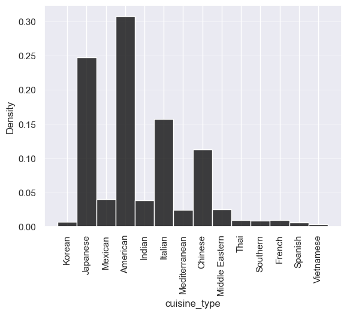

```python
# Generating a histogram for Cuisine Type analysis
sns.histplot(data=df,x='cuisine_type',stat='density',color = 'black')
plt.xticks(rotation=90)
plt.grid(axis='y', linewidth=0.5)
plt.show()
```

#### The most popular cuisine types include American encompassing around 30% of all orders and Japanese at around 25%

#### Let us look more closely at the percentage values:

```python
(df['cuisine_type'].value_counts())/df.shape[0]*100
#Gives percentages of each cuisine type ordered relative to total number of orders
```

```
American          30.769231
Japanese          24.762908
Italian           15.700738
Chinese           11.327713
Mexican            4.056902
Indian             3.846154
Middle Eastern     2.581665
Mediterranean      2.423604
Thai               1.001054
French             0.948367
Southern           0.895680
Korean             0.684932
Spanish            0.632244
Vietnamese         0.368809
Name: cuisine_type, dtype: float64
```

#### [2] Let us now see what are the most ordered from restaurants

```python
# Filtering for restaurants that have been ordered more than 20 times (pop_rest is short for popular restaurants)
pop_rest = df[df['restaurant_name'].isin(df['restaurant_name'].value_counts().index[df['restaurant_name'].value_counts().gt(20)])]
print('There are ' + str(pop_rest['restaurant_name'].nunique()) + ' restaurants that have been ordered more than 20 times')
pop_rest['restaurant_name'].unique()
```

```
There are 21 restaurants that have been ordered more than 20 times
```

```
array(['Blue Ribbon Sushi Izakaya', 'Blue Ribbon Fried Chicken',
       'Tamarind TriBeCa', 'The Meatball Shop', 'Shake Shack',
       'RedFarm Hudson', 'Blue Ribbon Sushi',
       'Five Guys Burgers and Fries', 'Sushi of Gari 46', 'TAO', 'Parm',
       'Chipotle Mexican Grill $1.99 Delivery', 'RedFarm Broadway',
       "Jack's Wife Freda", 'Blue Ribbon Sushi Bar & Grill',
       'Nobu Next Door', 'Han Dynasty', 'Rubirosa', 'Bareburger',
       'Momoya', 'Sushi of Gari Tribeca'], dtype=object)
```

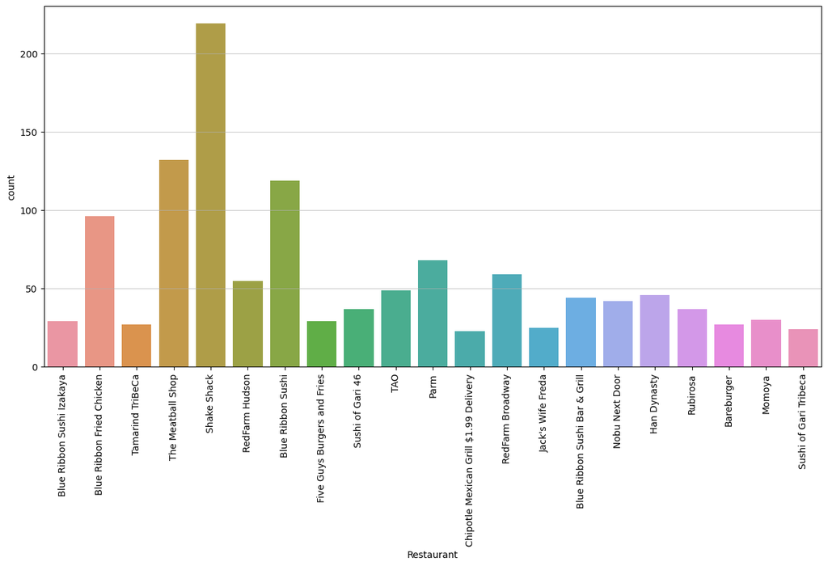

```python
# Generating a count plot for Restaurant Analysis
plt.figure(figsize=(15,7))
sns.countplot(data=pop_rest,x='restaurant_name')
plt.xlabel('Restaurant');
plt.grid(axis='y', linewidth=0.5)
plt.xticks(rotation=90)
plt.show()
```

#### - The most popular restaurant by far with over 200 orders is Shake Shack

#### - Only 3 restaurants have been ordered from more than 100 times: 'Shake Shack', 'The Meatball Shop' and 'Blue Ribbon Sushi'

#### [3] Analysing how the Order Costs are distributed

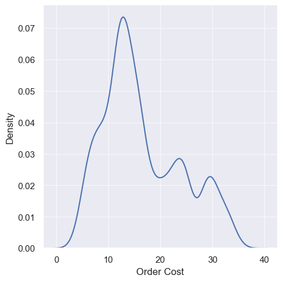

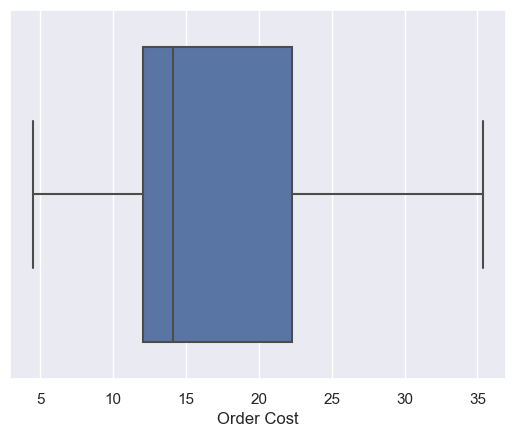

```python
# Generating a KDE for Price analysis
sns.displot(data=df,x='cost_of_the_order',kind='kde')
plt.xlabel('Order Cost')
plt.grid(linewidth=0.5)
plt.show()

# Generating a boxplot for Price analysis
sns.boxplot(data=df,x='cost_of_the_order')
plt.xlabel('Order Cost')
plt.show()
```

#### The Plots are skewed towards the right with the median price being around 14 and the mode being around 13

#### [4] Looking at how many meals are ordered on a weekday vs. a weekend

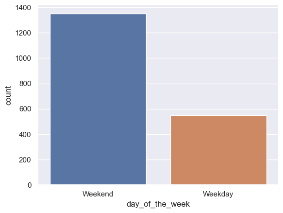

```
Weekend    1351
Weekday     547
Name: day_of_the_week, dtype: int64
```

```python
sns.countplot(data=df,x='day_of_the_week')
plt.show()
print(df['day_of_the_week'].value_counts()) # Prints total number of weekend and weekday occurances
```

#### A majority of meals are ordered on the Weekend

#### [5] Analyzing the time taken to prepare and deliver the orders

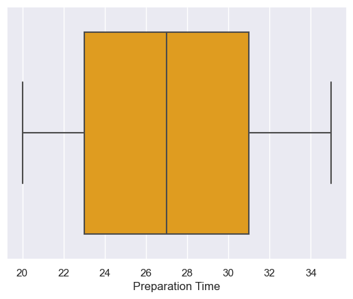

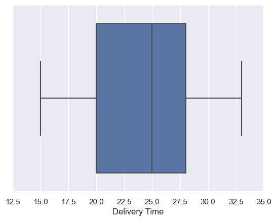

```python
sns.boxplot(data=df,x='food_preparation_time', color = 'orange')
plt.xlabel('Preparation Time')
plt.show()

sns.boxplot(data=df,x='delivery_time')
plt.xlabel('Delivery Time')
plt.xlim(12.5,35)
plt.show()
```

#### - Median Preparation Time is 27 minutes

#### - Median Delivery Time is 25 minutes where the median is partially left skewed

### Let us see analyze the total time from order to delivery

```python
# Creating a new column for total wait time which is calculated by adding the prep and delivery time
df['total_wait_time'] = df['food_preparation_time'] + df['delivery_time']
df.head()
```

|  | order_id | customer_id | restaurant_name | cuisine_type | cost_of_the_order | day_of_the_week | rating | food_preparation_time | delivery_time | total_wait_time |
| --- | --- | --- | --- | --- | --- | --- | --- | --- | --- | --- |
| 0 | 1477147 | 337525 | Hangawi | Korean | 30.75 | Weekend | Not given | 25 | 20 | 45 |
| 1 | 1477685 | 358141 | Blue Ribbon Sushi Izakaya | Japanese | 12.08 | Weekend | Not given | 25 | 23 | 48 |
| 2 | 1477070 | 66393 | Cafe Habana | Mexican | 12.23 | Weekday | 5 | 23 | 28 | 51 |
| 3 | 1477334 | 106968 | Blue Ribbon Fried Chicken | American | 29.20 | Weekend | 3 | 25 | 15 | 40 |
| 4 | 1478249 | 76942 | Dirty Bird to Go | American | 11.59 | Weekday | 4 | 25 | 24 | 49 |

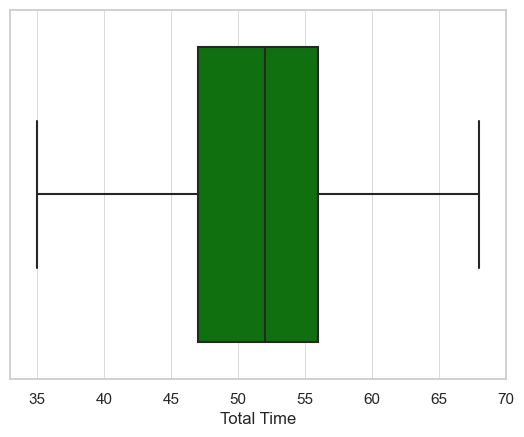

```python
# Creating a boxplot
sns.boxplot(data=df,x='total_wait_time', color = 'green')
plt.xlim(33,70)
plt.xlabel('Total Time')
plt.grid(axis='x', linewidth=0.5)
plt.show()
```

#### There are no outliers in the box plots, the shortest time total taken from order to delivery is 35 minutes while the longest is around 68 minutes with the median time being 52 minutes

#### [6] Analyzing the trend in ratings

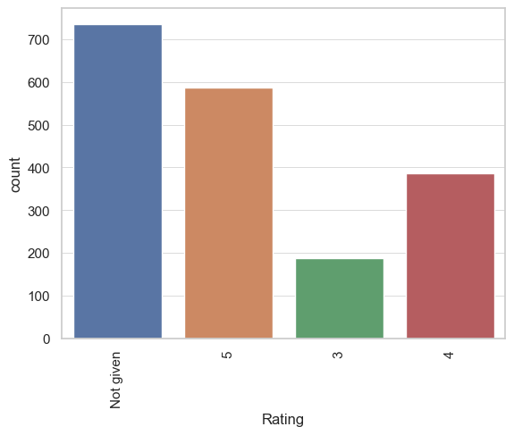

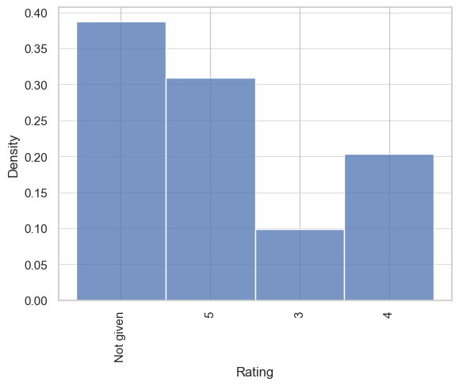

```python
# Generating a count plot for the ratings column
sns.countplot(data=df,x='rating')
plt.xlabel('Rating');
plt.grid(axis='y', linewidth=0.5)
plt.xticks(rotation=90)
plt.show()

# Generating a histogram plot for the ratings column
sns.histplot(data=df,x='rating',stat='density')
plt.xlabel('Rating');
plt.xticks(rotation=90)
plt.grid(axis='y', linewidth=0.5)
plt.show()
```

#### - No ratings below a 3 were given

#### - A large number of orders were not rated (approximately 38% of all orders)

#### - A majority of the orders that were rated received a rating of 5 (over 30% of all orders)

#### - Only 10% of orders were given a rating of 3

### **Question 7**: Which are the top 5 restaurants in terms of the number of orders received? [1 mark]

```python
df['restaurant_name'].value_counts().head()
# Displays top 5 most ordered restaurants and the number of orders they received
```

```
Shake Shack                  219
The Meatball Shop            132
Blue Ribbon Sushi            119
Blue Ribbon Fried Chicken     96
Parm                          68
Name: restaurant_name, dtype: int64
```

#### Observations:

1. Shake Shack
2. The Meatball Shop
3. Blue Ribbon Sushi
4. Blue Ribbon Fried Chicken
5. Parm

### **Question 8**: Which is the most popular cuisine on weekends? [1 mark]

```python
df.loc[df['day_of_the_week'] == 'Weekend']['cuisine_type'].value_counts()
# Displays most ordered cuisines during the weekend
```

```
American          415
Japanese          335
Italian           207
Chinese           163
Mexican            53
Indian             49
Mediterranean      32
Middle Eastern     32
Thai               15
French             13
Korean             11
Southern           11
Spanish            11
Vietnamese          4
Name: cuisine_type, dtype: int64
```

#### Observations: American Cuisine is the most popular during the weekends

### **Question 9**: What percentage of the orders cost more than 20 dollars? [2 marks]

```python
df.head()
```

|  | order_id | customer_id | restaurant_name | cuisine_type | cost_of_the_order | day_of_the_week | rating | food_preparation_time | delivery_time | total_wait_time |
| --- | --- | --- | --- | --- | --- | --- | --- | --- | --- | --- |
| 0 | 1477147 | 337525 | Hangawi | Korean | 30.75 | Weekend | Not given | 25 | 20 | 45 |
| 1 | 1477685 | 358141 | Blue Ribbon Sushi Izakaya | Japanese | 12.08 | Weekend | Not given | 25 | 23 | 48 |
| 2 | 1477070 | 66393 | Cafe Habana | Mexican | 12.23 | Weekday | 5 | 23 | 28 | 51 |
| 3 | 1477334 | 106968 | Blue Ribbon Fried Chicken | American | 29.20 | Weekend | 3 | 25 | 15 | 40 |
| 4 | 1478249 | 76942 | Dirty Bird to Go | American | 11.59 | Weekday | 4 | 25 | 24 | 49 |

```python
(df.loc[df['cost_of_the_order'] > 20.0].shape[0])/df.shape[0]*100
# Filters orders that cost greater than 20 dollars and divides it by total number of orders to get the percentage
```

```
29.24130663856691
```

#### Observations: Around 29.24% of all orders cost more than 20 dollars

### **Question 10**: What is the mean order delivery time? [1 mark]

```python
# To calc mean delivery time
df['delivery_time'].mean()
```

```
24.161749209694417
```

#### Observations: The mean delivery time is 24.16 minutes

### **Question 11:** The company has decided to give 20% discount vouchers to the top 3 most frequent customers. Find the IDs of these customers and the number of orders they placed. [1 mark]

```python
# Finding which customer ids repeat the most
df['customer_id'].value_counts()
```

```
52832     13
47440     10
83287      9
250494     8
259341     7
          ..
385426     1
254913     1
289597     1
74412      1
397537     1
Name: customer_id, Length: 1200, dtype: int64
```

#### Observations:

ID 52832: 13 Orders

ID 47440: 10 Orders

ID 83287: 9 Orders

### **Question 12**: Perform a multivariate analysis to explore relationships between the important variables in the dataset. (It is a good idea to explore relations between numerical variables as well as relations between numerical and categorical variables) [10 marks]

### [1] First let us see if there is any correlation between the numerical variables in the dataset via a Heatmap

[figure not shown]

```python
# Generating a Heatmap
plt.figure(figsize=(8,5))
sns.heatmap(df.corr(numeric_only=True),annot=True,cmap='crest',vmin=-1,vmax=1)
plt.show()
```

### [2] We will now look at if certain cuisine types are typically more expensive or take more time to prepare than others

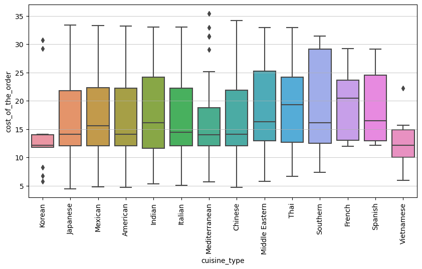

```
cuisine_type
Vietnamese        12.130
Korean            12.180
Mediterranean     13.995
Japanese          14.070
American          14.120
Chinese           14.120
Italian           14.480
Mexican           15.570
Southern          16.110
Indian            16.150
Middle Eastern    16.300
Spanish           16.520
Thai              19.350
French            20.470
Name: cost_of_the_order, dtype: float64
```

```python
# Generating a box plot of cost of order vs. cuisine type
plt.figure(figsize=(10,5))
sns.boxplot(data=df,x='cuisine_type',y='cost_of_the_order')
plt.xticks(rotation=90)
plt.grid(axis='y', linewidth=0.5)
plt.show()

# Printing the exact median prices of the cuisine types
df.groupby('cuisine_type')['cost_of_the_order'].median(numeric_only=True).sort_values()
```

### From the plot we can gather:

- Korean and Vietnamese food are cheapest options with a median of only 12.18 and 12.13 dollars respectively
- They also possess the smallest variations in price (aside from outliers) suggesting that they have the least number of restaurants, *we will explore this further*
- The most expensive cuisine is French followed closely by Thai cuisine with a median of 20.47 and 19.35 respectively

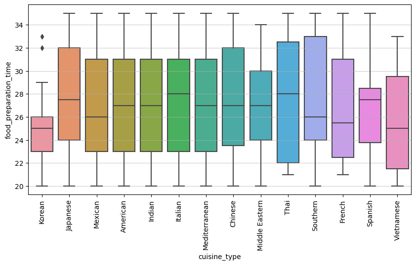

```
cuisine_type
Korean            25.0
Vietnamese        25.0
French            25.5
Mexican           26.0
Southern          26.0
American          27.0
Chinese           27.0
Indian            27.0
Mediterranean     27.0
Middle Eastern    27.0
Japanese          27.5
Spanish           27.5
Italian           28.0
Thai              28.0
Name: food_preparation_time, dtype: float64
```

```python
# Generating a box plot of food prep time vs. cuisine type
plt.figure(figsize=(10,5))
sns.boxplot(data=df,x='cuisine_type',y='food_preparation_time')
plt.xticks(rotation=90)
plt.grid(axis='y', linewidth=0.5)
plt.show()

# Printing the exact median prep time of the cuisine types
df.groupby('cuisine_type')['food_preparation_time'].median(numeric_only=True).sort_values()
```

### From the plot we can gather:

- All median values are very similar to one another varying only from 25 to 28 minutes
- Korean food possesses the least varied food prep time with the smallest box plot area once again suggesting that there are fewer korean restaurants
- Thai food consists of the largest box plot area indicating it having the most varied/inconsistent food prep time

### [3] Let us look at the exact number of restaurants availble to order from for each cuisine type

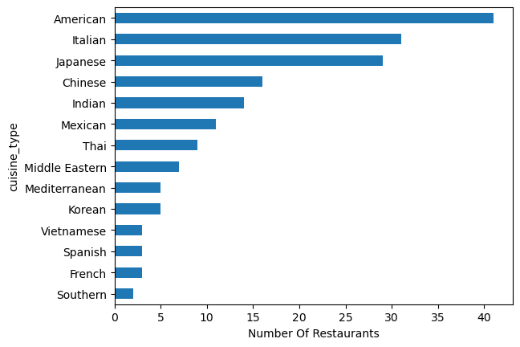

```python
# Producing a bar plot of the number of restaurants available for each cuisine type
df.groupby('cuisine_type')['restaurant_name'].nunique().sort_values().plot.barh()
plt.xlabel('Number Of Restaurants');
```

- While the initial hypothesis of Korean cuisine having a 'low' number of restaurants is correct, there are still other cusines with fewer restaurants (Vietnamese, Spanish, French and Southern) suggesting that the 5 Korean restaurants available have similarly prices food
- There are only 2 Southern restaurants available to order from
- There are only 3 French restaurants however with the median cost of French food being the highest it indicates that the few restaurants available provide relatively expensive dishes
- While there are a similar number of Indian and Chinese restaurants, Chinese cuisine is ordered roughly *3 times* more often than Indian cuisine

#### Chinese cuisine is being ordered far more frequently than Indian cuisines despite having a similar number of restaurants, let's see if the ratings provide any insight

### [4] Let's analyze the rating distributions based on cuisine type

```
cuisine_type
American    4.298913
Chinese     4.338346
Indian      4.540000
Italian     4.360465
Japanese    4.373626
Name: rating, dtype: float64
```

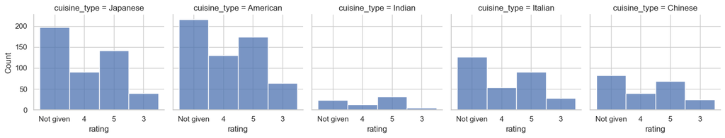

```python
# Filtering the dataset by only including cuisine types which are ordered from the most (> 0.1 density) as well as Indian
# We are only analysing these cuisines as there is insufficient order data for other cuisine types to make a reliable conclusion
df_filtered = df[df['cuisine_type'].isin(['American', 'Japanese', 'Chinese', 'Italian', 'Indian'])]
g = sns.FacetGrid(df_filtered, col="cuisine_type")
g.map(sns.histplot, "rating");

# Eliminating unrated orders and converting the datatype to float to find the average rating for each cuisine type
df_filtered = df_filtered[df_filtered['rating']!='Not given']
df_filtered['rating'] = df_filtered['rating'].astype(float)
df_filtered.groupby('cuisine_type')["rating"].mean()

# Double click the graphs to zoom
```

- The cuisine types follow the same general trend with a majority of orders being unrated, followed by a 5 rating, then a 4 and the rating of a 3 being the least frequent
- The exception is Indian cuisine however, with more 5 ratings than unrated orders
- The average rating for the above mentioned cuisine types all float around 4.3 - 4.4 with the exception of Indian
- Surprisingly Indian cuisine has a significantly higher rating than other cuisines, despite not being ordered from too often

### [5] Analyzing weekend and weekday statistics - cost of orders and delivery time

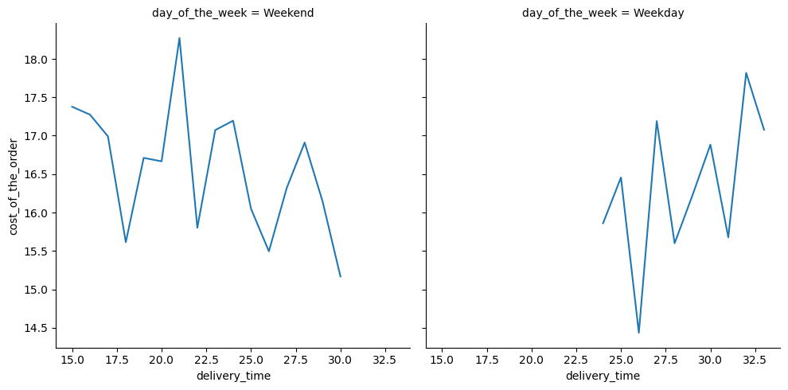

```
22.4700222057735
16.574833456698745
28.340036563071298
16.311188299817182
```

```python
sns.relplot(data=df,x='delivery_time',y='cost_of_the_order',col='day_of_the_week',kind='line', ci=None, col_wrap=2)
plt.show()

print((df[df['day_of_the_week'] == 'Weekend'])['delivery_time'].mean()) # Average delivery time of weekend orders
print((df[df['day_of_the_week'] == 'Weekend'])['cost_of_the_order'].mean()) # Average cost of weekend orders

print((df[df['day_of_the_week'] == 'Weekday'])['delivery_time'].mean()) # Average delivery time of weekday orders
print((df[df['day_of_the_week'] == 'Weekday'])['cost_of_the_order'].mean()) # Average cost of weekday orders
```

- On average, delivery times of Weekend orders are significantly less than that of weekday orders (around 20% or just under 6 minutes faster)
- Cost of orders on weekends and weekdays are roughly the same with the average around 16.5 dollars per order for both

### **Question 13:** The company wants to provide a promotional offer in the advertisement of the restaurants. The condition to get the offer is that the restaurants must have a rating count of more than 50 and the average rating should be greater than 4. Find the restaurants fulfilling the criteria to get the promotional offer. [3 marks]

```python
df_filtered = df[df['rating']!='Not given'] # Creating a copy of the dataset without unrated orders
df_filtered['rating'] = df_filtered['rating'].astype(float) #Converting datatype from object to float
df_filtered.info()
```

[output not shown]

```python
# Group the ratings with the restaurants and display all restaurants with over 50 customer ratings
series_filtered = df_filtered.groupby('restaurant_name')['rating'].count() > 50
series_filtered[series_filtered].index
```

```
Index(['Blue Ribbon Fried Chicken', 'Blue Ribbon Sushi', 'Shake Shack',
       'The Meatball Shop'],
      dtype='object', name='restaurant_name')
```

```python
# Finding the average ratings of those 4 restaurants
df_filtered.groupby('restaurant_name')['rating'].mean()[series_filtered[series_filtered].index]
```

```
restaurant_name
Blue Ribbon Fried Chicken    4.328125
Blue Ribbon Sushi            4.219178
Shake Shack                  4.278195
The Meatball Shop            4.511905
Name: rating, dtype: float64
```

#### Observations:

- The restaurants that fulfill the criteria are: 'Blue Ribbon Fried Chicken', 'Blue Ribbon Sushi', 'Shake Shack' and 'The Meatball Shop'

### **Question 14:** The company charges the restaurant 25% on the orders having cost greater than 20 dollars and 15% on the orders having cost greater than 5 dollars. Find the net revenue generated by the company across all orders. [3 marks]

```python
# Creating a new column for per order company revenue and filtering and calculating by the first condition (> $20 orders)
df['per_order_revenue'] = df[df['cost_of_the_order'] > 20]['cost_of_the_order'] * 0.25

# Since there are only 2 conditions, the remaining cells will be filled with NaN values
# We can safely say these cells fulfil the other condition and apply that accordingly
df['per_order_revenue'].fillna(value = df['cost_of_the_order']*0.15, inplace = True)

# Summing the order revenue column to get the total revenue
df['per_order_revenue'].sum()
```

```
6172.714
```

### **Question 15:** The company wants to analyze the total time required to deliver the food. What percentage of orders take more than 60 minutes to get delivered from the time the order is placed? (The food has to be prepared and then delivered.) [2 marks]

```python
# Calculating the percentage of rows where total wait time is greater than 60 to the total number of orders
(df[df['total_wait_time'] > 60].shape[0]) / df.shape[0] *100
```

```
10.537407797681771
```

### **Question 16:** The company wants to analyze the delivery time of the orders on weekdays and weekends. How does the mean delivery time vary during weekdays and weekends? [2 marks]

```python
# Filtering by weekend/weekday and finding the mean (using string convertion and rounding for printing)
print('The average delivery time on weekends is ' +
      str(round((df[df['day_of_the_week'] == 'Weekend'])['delivery_time'].mean(), 2)) +
      ' minutes')


print('The average delivery time on weekdays is ' +
      str(round((df[df['day_of_the_week'] == 'Weekday'])['delivery_time'].mean(), 2)) +
      ' minutes')

print('On average, weekend orders are delivered ' +
      str(round((28.34-22.47), 2)) +
      ' minutes faster than orders placed on the weekdays')
```

```
The average delivery time on weekends is 22.47 minutes
The average delivery time on weekdays is 28.34 minutes
On average, weekend orders are delivered 5.87 minutes faster than orders placed on the weekdays
```

#### Observations:

- The average delivery time on weekends is 22.47 minutes
- The average delivery time on weekdays is 28.34 minutes
- On average, weekend orders are delivered 5.87 minutes faster than orders placed on the weekdays

### Recommendations:

- Encourage customers to rate their orders by providing incentives (such as vouchers/redeemable points, etc.) this will reduce the number of unrated orders
- Indian cuisine is rated well but not ordered from too frequently, you can market and promote indian restaurants more on the app and try to incentivise customers with a first time order discount for customers who have not ordered Indian cuisine yet
- Try to work more closely with the most ordered from restaurants such as Shake Shack and the Blue Ribbon franchises to take advantage of the large number of orders. You can try to create an app exclusive menu item for those restaurants that can provide a greater revenue share per order
- Having a large majority of orders on the Weekend is great as they can be fulfilled faster due to a shorter delivery time, maintaining this is beneficial
- You can optimize revenue gained through promoting and fulfilling more French cuisine orders as they take one of the shortest times to prepare on average and have the highest order cost